# R Notebook

```r
library(tidyverse)
library(tibble)
library(readr)
library(knitr)
```

# Spørsmål 1

Filen ddf_concepts.csv inneholder all mulig informasjon og ikke datasett, men 596 beskrivelser. Man kan for eksempel se at de har beskrivelser av alder av første ekteskap, arbeidsledighet, sykdom, dødsfall og alkoholkonsum.

# Spørsmål 2

Filen ddf–entities-geo–country.csv gir oss et inblikk i ulike land, inntektensgrupperinger, hvilken religion de tilhører, annen geografisk informajson som for eksempel størrelse på landet og lokasjon, breddegrader osv.

# Spørsmål 3

Filen dff-gapminder inneholder en tabell over regionene som er med i FN.

# Spørsmål 4

```r
library(readr)
g_c <- read_csv("Data/ddf--gapminder--systema_globalis-master/ddf--entities--geo--country.csv")
as_tibble(g_c)
```

| country | g77_and_oecd_countries | income_3groups | income_groups | is--country | iso3166_1_alpha2 | iso3166_1_alpha3 | iso3166_1_numeric | iso3166_2 | landlocked | latitude | longitude | main_religion_2008 | name | un_sdg_ldc | un_sdg_region | un_state | unicef_region | unicode_region_subtag | world_4region | world_6region |
| --- | --- | --- | --- | --- | --- | --- | --- | --- | --- | --- | --- | --- | --- | --- | --- | --- | --- | --- | --- | --- |
| abkh | others | NA | NA | TRUE | NA | NA | NA | NA | NA | NA | NA | NA | Abkhazia | NA | NA | FALSE | NA | NA | europe | europe_central_asia |
| abw | others | high_income | high_income | TRUE | AW | ABW | 533 | NA | coastline | 12.50000 | -69.96667 | christian | Aruba | un_not_least_developed | un_latin_america_and_the_caribbean | FALSE | NA | AW | americas | america |
| afg | g77 | low_income | low_income | TRUE | AF | AFG | 4 | NA | landlocked | 33.00000 | 66.00000 | muslim | Afghanistan | un_least_developed | un_central_and_southern_asia | TRUE | sa | AF | asia | south_asia |
| ago | g77 | middle_income | lower_middle_income | TRUE | AO | AGO | 24 | NA | coastline | -12.50000 | 18.50000 | christian | Angola | un_least_developed | un_sub_saharan_africa | TRUE | ssa | AO | africa | sub_saharan_africa |
| aia | others | NA | NA | TRUE | AI | AIA | 660 | NA | coastline | 18.21667 | -63.05000 | christian | Anguilla | un_not_least_developed | un_latin_america_and_the_caribbean | FALSE | NA | AI | americas | america |
| akr_a_dhe | others | NA | NA | TRUE | NA | NA | NA | NA | coastline | NA | NA | NA | Akrotiri and Dhekelia | NA | NA | FALSE | NA | NA | europe | europe_central_asia |
| ala | others | NA | NA | TRUE | AX | ALA | 248 | NA | coastline | 60.25000 | 20.00000 | NA | Åland | un_not_least_developed | un_europe_and_northern_america | FALSE | NA | AX | europe | europe_central_asia |
| alb | others | middle_income | upper_middle_income | TRUE | AL | ALB | 8 | NA | coastline | 41.00000 | 20.00000 | muslim | Albania | un_not_least_developed | un_europe_and_northern_america | TRUE | eca | AL | europe | europe_central_asia |
| and | others | high_income | high_income | TRUE | AD | AND | 20 | NA | landlocked | 42.50779 | 1.52109 | christian | Andorra | un_not_least_developed | un_europe_and_northern_america | TRUE | eca | AD | europe | europe_central_asia |
| ant | others | NA | NA | TRUE | NA | NA | NA | NA | coastline | NA | NA | NA | Netherlands Antilles | NA | NA | FALSE | NA | NA | americas | america |

[output cut: 263 more lines]

```r
g_c <- g_c %>%
  mutate(continent = case_when(
     world_4region == "asia" & un_sdg_region %in% c("un_australia_and_new_zealand", "un_oceania_exc_australia_and_new_zealand") ~ "Oceania",
    world_4region ==  "asia" & !(un_sdg_region %in% c("un_australia_and_new_zealand", "un_oceania_exc_australia_and_new_zealand")) ~ "Asia",
    world_4region == "africa" ~ "Africa",
    world_4region == "americas" ~ "Americas",
    world_4region ==  "europe" ~ "Europe")
  ) %>%
 filter(!is.na(iso3166_1_alpha3))
```

# Spørsmål 5

```r
length(unique(g_c$country))
```

```
## [1] 247
```

Det er nå 247 land. Tidligere 273 men vil valgte å filtrere ut utdaterte land.

# Spørsmål 6

```r
g_c %>%
  group_by(continent) %>%
  summarise(count = length(unique(country)))
```

| continent | count |
| --- | --- |
| Africa | 59 |
| Americas | 55 |
| Asia | 47 |
| Europe | 58 |
| Oceania | 28 |

Som vi kan lese av i tabellen ovenfor, er det 59 land i Afrika, 55 land i Amerika, 47 land i Asia, 58 land i Europa og 28 land i Oseania som er involverte i datasettet.

# Spørsmål 7

```r
lifeExp <-read_csv("Data/ddf--gapminder--systema_globalis-master/countries-etc-datapoints/ddf--datapoints--life_expectancy_years--by--geo--time.csv",col_types =cols(time =col_date(format = "%Y")))


lifeExp <- lifeExp%>%
  rename(year = time)

length(unique(lifeExp$geo))
```

```
## [1] 189
```

Det er 189 land som har informasjon om life Expectancy.

# spørsmål 8

```r
names(g_c)
```

```
##  [1] "country"                "g77_and_oecd_countries" "income_3groups"
##  [4] "income_groups"          "is--country"            "iso3166_1_alpha2"
##  [7] "iso3166_1_alpha3"       "iso3166_1_numeric"      "iso3166_2"
## [10] "landlocked"             "latitude"               "longitude"
## [13] "main_religion_2008"     "name"                   "un_sdg_ldc"
## [16] "un_sdg_region"          "un_state"               "unicef_region"
## [19] "unicode_region_subtag"  "world_4region"          "world_6region"
## [22] "continent"
```

```r
g_c <- g_c %>%
  select(country, name, iso3166_1_alpha3, main_religion_2008,un_sdg_region, world_4region, continent, world_6region,)%>%
  left_join(lifeExp, by =c("country" = "geo"))%>%
  filter(!(is.na(year)& is.na(life_expectancy_years)))%>%
  filter(year<"2020-01-01")
rm(lifeExp)
```

Her har vi valgt ut ti varaibler fra datasettet.

# spørsmål 9

```r
g_c_min <- g_c %>%
  group_by(country) %>%
  summarise(year_min = min(year))

g_c_min %>%
  count(min_year = g_c_min$year_min)
```

| min_year | n |
| --- | --- |
| 1800-01-01 | 186 |
| 1970-01-01 | 3 |

```r
table(g_c_min$year_min)
```

```
##
## 1800-01-01 1970-01-01
##        186          3
```

Vi kan se at det er tre land som startet obsevasjonene i 1970, og 186 land som startet observasjonene i 1800.

```r
g_c_min %>%
  filter(year_min =="1970-01-01")
```

| country | year_min |
| --- | --- |
| and | 1970-01-01 |
| dma | 1970-01-01 |
| mhl | 1970-01-01 |

Her har vi funnet de tre landene som startet observasjonene i 1970.

```r
g_c_min <- g_c_min %>%
  left_join(g_c,
            by = "country") %>%
  filter(year_min == "1970-01-01")

tibble(country=unique(g_c_min$name))
```

| country |
| --- |
| Andorra |
| Dominica |
| Marshall Islands |

I oppgave 9 de tre navnene (Andorra, Dominica, Marshall Island) som har de korteste seriene av life expectancy.

# Spørsmål 10

```r
g_c_pop <- read_csv("Data/ddf--gapminder--systema_globalis-master/countries-etc-datapoints/ddf--datapoints--population_total--by--geo--time.csv",
col_types =cols(time =col_date(format = "%Y")))

g_c <- g_c%>%
  left_join(g_c_pop, by =c("country" = "geo", "year" = "time"))
```

Denne viser oss hvordan populasjonen øker over tid, ved å se på 59 297 observasjoner, tabellen inneholder tre ulike variabler; land, tid og populasjon.

# Spørsmål 11

```r
u_pop <- read_csv("Data/ddf--gapminder--systema_globalis-master/countries-etc-datapoints/ddf--datapoints--urban_population--by--geo--time.csv",
col_types =cols(time =col_date(format = "%Y")))
```

# Spørsmål 12

```r
gdp_pc <- read_csv("Data/ddf--gapminder--systema_globalis-master/countries-etc-datapoints/ddf--datapoints--gdppercapita_us_inflation_adjusted--by--geo--time.csv",
col_types =cols(time =col_date(format = "%Y")))
```

```r
g_c <- g_c %>%
  left_join(gdp_pc, by=c("country"="geo", "year"="time"))
```

```r
names(g_c)
```

```
##  [1] "country"                            "name"
##  [3] "iso3166_1_alpha3"                   "main_religion_2008"
##  [5] "un_sdg_region"                      "world_4region"
##  [7] "continent"                          "world_6region"
##  [9] "year"                               "life_expectancy_years"
## [11] "population_total"                   "gdppercapita_us_inflation_adjusted"
```

# Spørsmål 13

```r
g_c <- g_c %>%
  rename("lifeExp" = "life_expectancy_years") %>%
  rename("pop" = "population_total") %>%
  rename("gdpPercap" = "gdppercapita_us_inflation_adjusted")
```

```r
t1 <- paste(seq(1962, 2017, by = 5), "01-01", sep = "-") %>% parse_date(format = "%Y-%m-%d")
my_gapminder <- g_c %>%
  filter(year %in% t1) %>%
  select(name, continent, year, lifeExp, pop, gdpPercap) %>%
  rename("country" = "name")
```

```r
dim(my_gapminder)
```

```
## [1] 2262    6
```

Etter å ha filtrer årene, kan vi se at vi får 2262 observasjoner fordelt på seks variabler.

# Spørsmål 14

```r
my_gapminder_1962 <- my_gapminder %>%
  group_by(country) %>%
  filter(!is.na(gdpPercap)) %>%
  filter(year == "1962-01-01")
length(unique(my_gapminder_1962$country))
```

```
## [1] 90
```

Her kan vi se at det er 90 land som startet i 1962 har data fra gdpPercap.

```r
my_gapminder_1962 %>%
distinct(country, continent) %>%
group_by(continent) %>%
count() %>%
kable()
```

| continent | n |
| --- | --- |
| Africa | 30 |
| Americas | 25 |
| Asia | 17 |
| Europe | 15 |
| Oceania | 3 |

Her kan vi se at det er 30 land i Afrika, 25 land i Amerika, Asia 17, Europa 15 og 3 land i oseania.

```r
c_min_y <- my_gapminder %>%
filter(!is.na(gdpPercap)) %>%
group_by(country) %>%
summarise(min_year = min(year))
c_min_y_62 <- c_min_y$country[c_min_y$min_year == "1962-01-01"]
```

```r
my_gapminder_1962 <- my_gapminder %>%
filter(country %in% c_min_y_62)
dim(my_gapminder_1962)
```

```
## [1] 1080    6
```

```r
sum(is.na(my_gapminder_1962$gdpPercap))
```

```
## [1] 1
```

```r
my_gapminder_1962 %>%
  group_by(country) %>%
  filter(is.na(gdpPercap)) %>%
  tibble()
```

| country | continent | year | lifeExp | pop | gdpPercap |
| --- | --- | --- | --- | --- | --- |
| Venezuela | Americas | 2017-01-01 | 75.29 | 29402480 | NA |

# Spørsmål 15

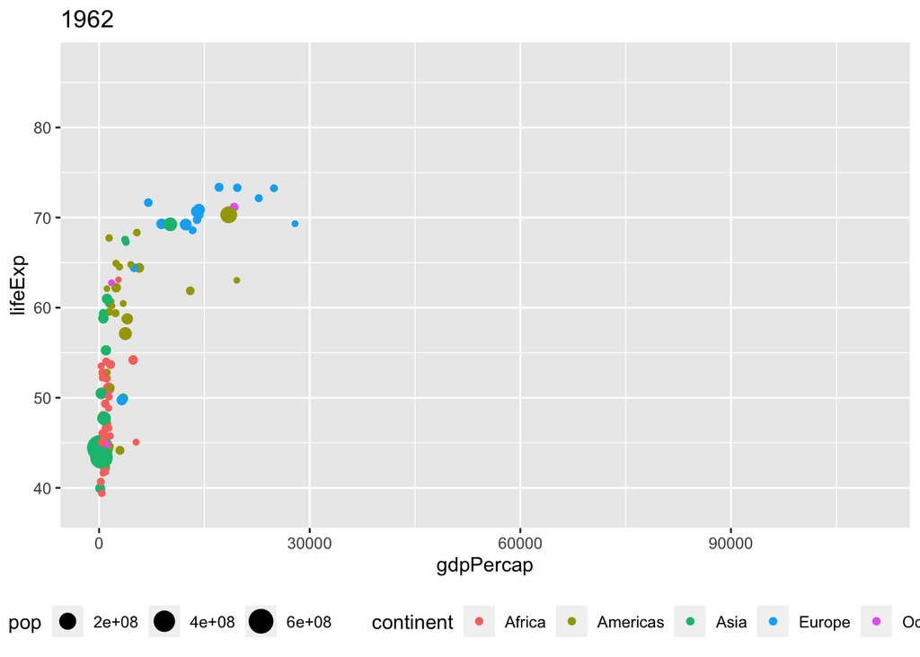

```r
my_gapminder_1962 %>%
  # dere har gelemt å plukke ut verdiene for år 1962
  filter(year == "1962-01-01") %>%
  ggplot(my_gapminder_1962,
         mapping = aes(
           x = gdpPercap,
           y = lifeExp,
           size = pop,
           colour = continent
           )
         ) +
  coord_cartesian(ylim = c(38, 87), xlim = c(0,110000)) +
  geom_point() +
  ggtitle("1962") +
  theme(legend.position = "bottom")
```

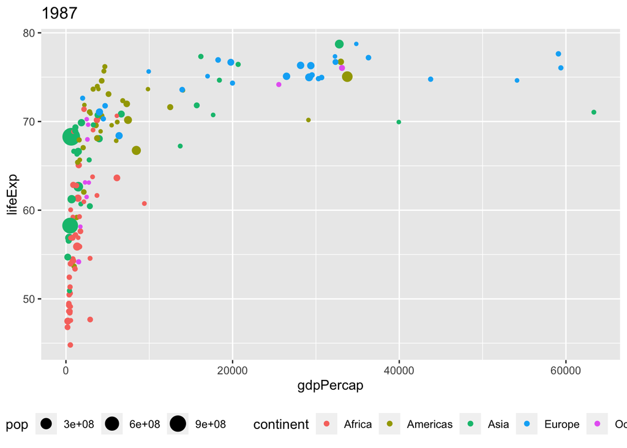

```r
my_gapminder_1987 <- my_gapminder %>%
  group_by(country) %>%
  filter(!is.na(gdpPercap)) %>%
  filter(year == "1987-01-01")

my_gapminder_1987 %>%
  ggplot(my_gapminder_1987, mapping=aes(x=gdpPercap, y=lifeExp, size=pop, colour=continent)) +
  geom_point()+
  ggtitle("1987")+
  theme(legend.position = "bottom")
```

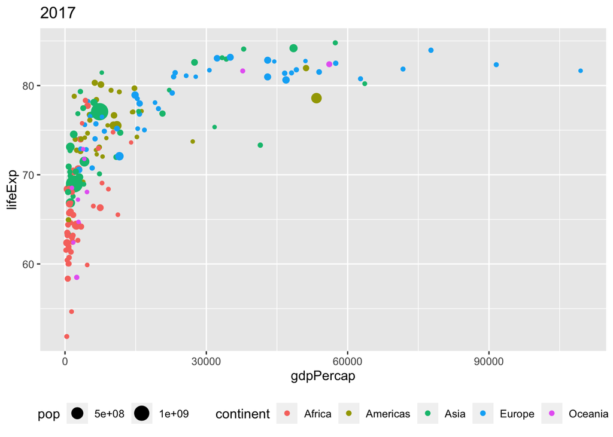

```r
# OK, men jeg forslår å bruke my_gapminder_1962 og filter på
# denne for årene 1962, 1987 og 2017. Gir mye mer clean code
# alle dataene ligger jo i my_gapminder_1962 og er lette å hente ut
my_gapminder_2017 <- my_gapminder %>%
  group_by(country) %>%
  filter(!is.na(gdpPercap)) %>%
  filter(year == "2017-01-01")

my_gapminder_2017 %>%
  ggplot(my_gapminder_2017, mapping=aes(x=gdpPercap, y=lifeExp, size=pop, colour=continent)) +
  geom_point()+
  ggtitle("2017")+
  theme(legend.position = "bottom")
```

## Hva jeg ville gjort

1. Bruker bare my_gapminder_1962 og plukker ut data for årene 1962, 1987 og 2017 fra denne vha `filter()`
2. Setter aksene like i de tre figurene slik at det er lettere å se hva som skjer over tid

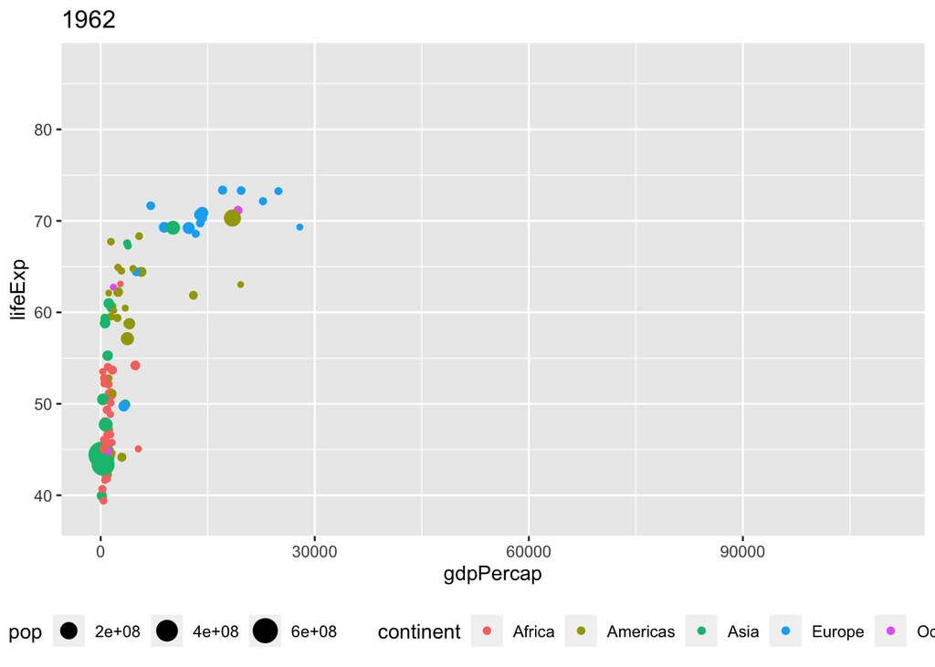

```r
my_gapminder_1962 %>%
  # dere har gelemt å plukke ut verdiene for år 1962
  filter(year == "1962-01-01") %>%
  ggplot(my_gapminder_1962,
         mapping = aes(
           x = gdpPercap,
           y = lifeExp,
           size = pop,
           colour = continent
           )
         ) +
  # lurt å sette aksene slik at de er like i de tre plottene
  # ellers er det vanskelig å sammenligne
  coord_cartesian(ylim = c(38, 87), xlim = c(0,110000)) +
  geom_point() +
  ggtitle("1962") +
  theme(legend.position = "bottom")
```

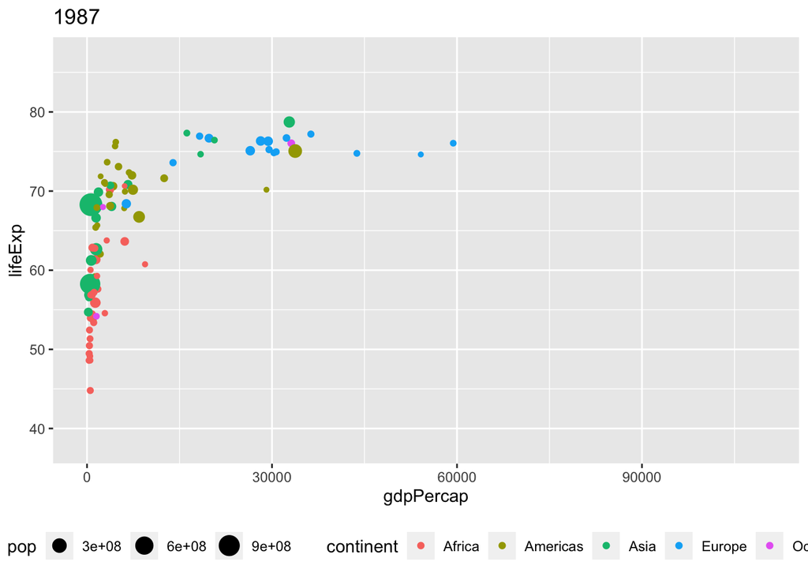

```r
# Hvorfor ikke bare bruke my_gapminder_1962 og plukke
# ut verdiene for år 1987? Mye enklere
my_gapminder_1962 %>%
  filter(year == "1987-01-01") %>%
  ggplot(my_gapminder_1962,
    mapping = aes(
      x = gdpPercap,
      y = lifeExp,
      size = pop,
      colour = continent
    )
  ) +
  coord_cartesian(ylim = c(38, 87), xlim = c(0,110000)) +
  geom_point() +
  ggtitle("1987") +
  theme(legend.position = "bottom")
```

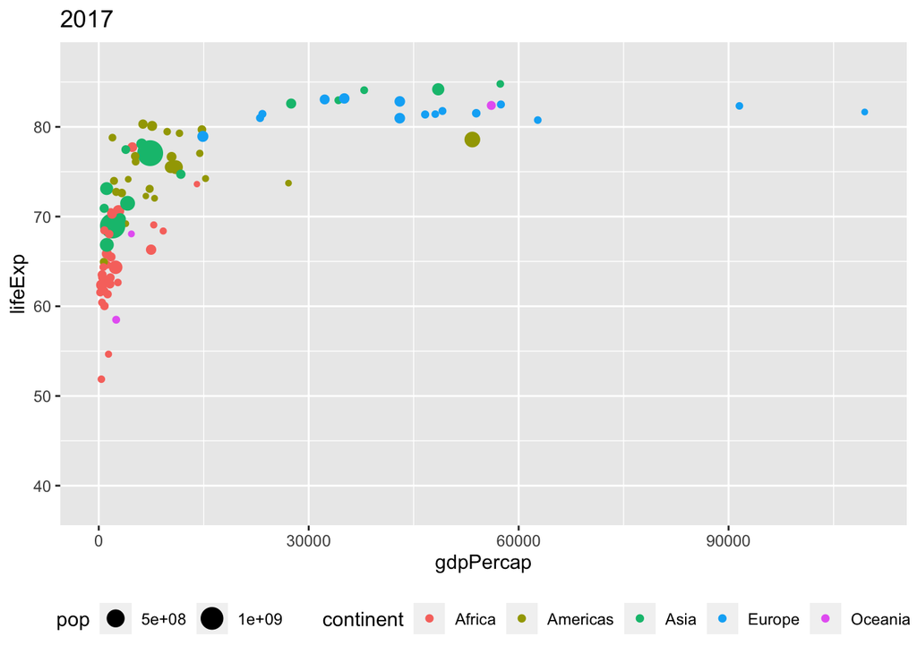

```r
my_gapminder_1962 %>%
  filter(year == "2017-01-01") %>%
  ggplot(my_gapminder_1962,
    mapping = aes(
      x = gdpPercap,
      y = lifeExp,
      size = pop,
      colour = continent
    )
  ) +
  # lurt å sette aksene slik at de er like i de tre plottene
  # ellers er det vanskelig å sammenligne
  coord_cartesian(ylim = c(38, 87), xlim = c(0,110000)) +
  # na.rm = TRUE så slipper vi advarsel for Venezuela
  geom_point(na.rm = TRUE) +
  ggtitle("2017") +
  theme(legend.position = "bottom")
```

# Spørsmål 16

[figure not shown]

```r
# my_gapminder_1962 inneholde data for hver femte år i perioden
# 1962 til 2017. Dere må plukke ut data for 1962

my_gapminder_1962 %>%
  ggplot(my_gapminder_1962, mapping=aes(x=log(gdpPercap), y=lifeExp, size=pop, colour=continent)) +
  geom_point()+
  coord_cartesian(xlim = c(5, 12), ylim = c(30, 100))+
  ggtitle("1962")+
  theme(legend.position = "bottom")
```

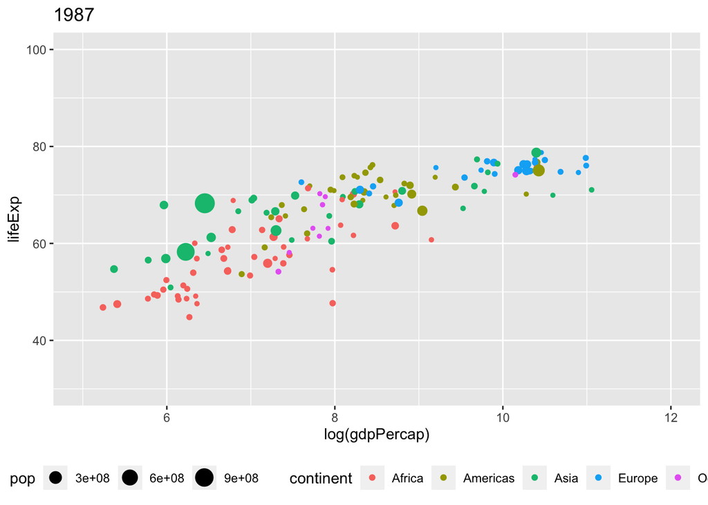

```r
my_gapminder_1987 %>%
  ggplot(my_gapminder_1987, mapping=aes(x=log(gdpPercap), y=lifeExp, size=pop, colour=continent)) +
  geom_point()+
  coord_cartesian(xlim = c(5, 12), ylim = c(30, 100))+
  ggtitle("1987")+
  theme(legend.position = "bottom")
```

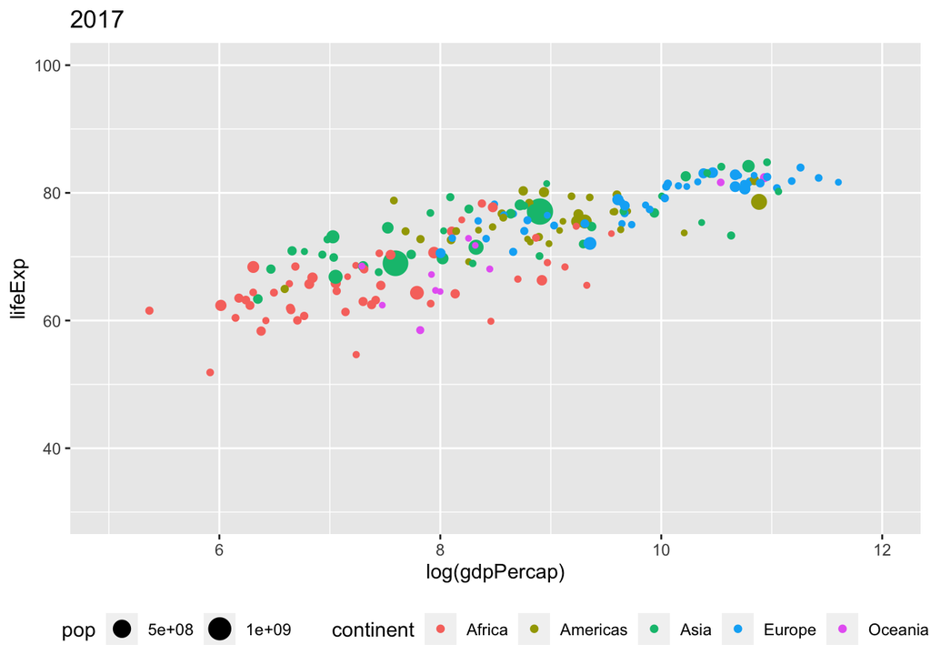

```r
my_gapminder_2017 %>%
  ggplot(my_gapminder_2017, mapping=aes(x=log(gdpPercap), y=lifeExp, size=pop, colour=continent)) +
  geom_point()+
  coord_cartesian(xlim = c(5, 12), ylim = c(30, 100))+
  ggtitle("2017")+
  theme(legend.position = "bottom")
```

# Spørsmål 17

Leser vi først av grafen fra spørsmål 15 kan vi se bnp på x-aksen og levealder på y-aksen. Størrelsen på punktene viser til hvor mange innbyggere det er i landene i de forskjellige kontinentene. Vi kan først i 1962 se at Europa som har en høy BNP, også har en høy levealder. I motsetning til Europa, har landene i Afrika og Asia som har en relativt lav bnp, også en lav levealder. Det kan derfor være en sammenheng mellom BNP og levealder.

Leser vi av grafen fra 1987 kan man med en gang legge merke til at det har vært en endring i Asia. Det vil si at Asia begynner å få en høyere levealder enn de hadde i 1962. Man kan også se i 2017 at Afrika også begynner å ta seg opp i levealder.

Ser man på logaritmen til de forskjellige årstallene, kan man se at alle kontinentene har fått en positivt utvikling av bnp. Asia skiller seg mest ut, som har hatt en svært positiv utivkling av bnp. Man kan se at vi fått samlet inn mer data av Bnp og levealder fra flere land. Alt i alt kan man se at levealderen i perioden fra 1962 til 2017, har steget hos alle kontinentene.

[output not shown]